# Titanic: Machine Learning from Disaster

Casey Quinn

February 10, 2016

```r
library(dplyr) # Data wrangling
library(tidyr) # Data wrangling
library(caret) # Machine learning
library(ggplot2) # Plotting
library(VIM) # Data visulazation
library(mice) # Data visulazation
library(stringr) # For string manipulation
library(xtable)
```

# Overview

The Titanic: Machine Learning from Disaster competition posted on [`Kaggle`](https://www.kaggle.com/c/titanic) was used to learn about and apply various machine learning techniques including K-nearest neighbors (KNN), naive Bayes, logistic regression, classification trees, bagging, random forests, boosting, and support vector machines (SVM). This document will provide an overview of the techniques applied and a comparison of the results.

# Data

The [`Kaggle website`](https://www.kaggle.com/c/titanic/data) provides two primary data sets; train.csv and test.csv. The train dataset consists of 891 observations and 11 potential predictor variables (PassengerId, Pclass, Name, Sex, Age, SibSp, Parch, Ticket, Fare, Cabin, Embarked) and 1 outcome variable (Survived). The test dataset consists of 418 observations and the same 11 predictor variables and no oucome varible.

The data files were first downloaded and loaded into R and a couple of the variables were reclassified:

```r
my_dir <- "C:/Docs/Dropbox/PhD/classes/STAT695/Titanic/"
setwd(my_dir)

train <- read.csv("data/train.csv")%>%
  mutate(Survived = factor(Survived),
  Pclass = factor(Pclass),
  Name = as.character(Name),
  Sex = factor(Sex))

test <- read.csv("data/test.csv")%>%
  mutate(Pclass = factor(Pclass),
  Name = as.character(Name),
  Sex = factor(Sex))
```

Once loaded into R, the datasets were parsed for missing values using the mice and VIM packages. The results for both the train and test datasets are shown in the tables and figures below.

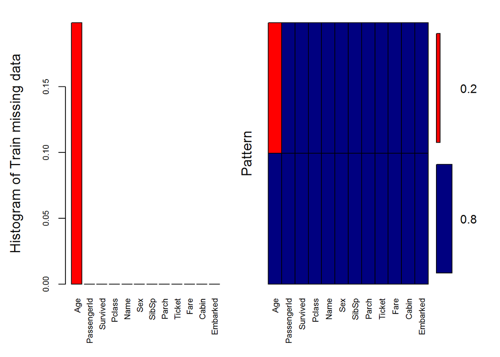

```
##
##  Variables sorted by number of missings:
##     Variable     Count
##          Age 0.1986532
##  PassengerId 0.0000000
##     Survived 0.0000000
##       Pclass 0.0000000
##         Name 0.0000000
##          Sex 0.0000000
##        SibSp 0.0000000
##        Parch 0.0000000
##       Ticket 0.0000000
##         Fare 0.0000000
##        Cabin 0.0000000
##     Embarked 0.0000000
```

```r
aggr_plot <- aggr(train, col=c('navyblue','red'), numbers=TRUE, sortVars=TRUE,
                  labels=names(data), cex.axis=.7, gap=3,
                  ylab=c("Histogram of Train missing data","Pattern"))
```

```r
train_md <- md.pattern(train)
knitr::kable(train_md)
```

|  | PassengerId | Survived | Pclass | Sex | SibSp | Parch | Ticket | Fare | Cabin | Embarked | Age | Name |  |
| --- | --- | --- | --- | --- | --- | --- | --- | --- | --- | --- | --- | --- | --- |
| 714 | 1 | 1 | 1 | 1 | 1 | 1 | 1 | 1 | 1 | 1 | 1 | 0 | 1 |
| 177 | 1 | 1 | 1 | 1 | 1 | 1 | 1 | 1 | 1 | 1 | 0 | 0 | 2 |
|  | 0 | 0 | 0 | 0 | 0 | 0 | 0 | 0 | 0 | 0 | 177 | 891 | 1068 |

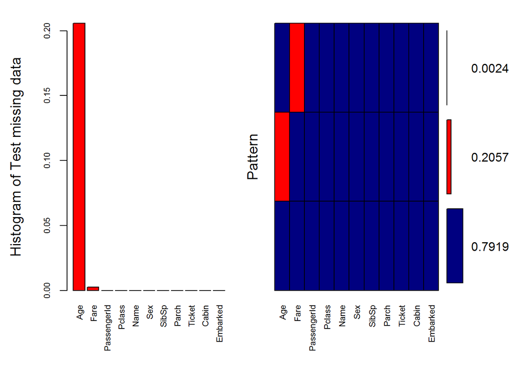

```
##
##  Variables sorted by number of missings:
##     Variable       Count
##          Age 0.205741627
##         Fare 0.002392344
##  PassengerId 0.000000000
##       Pclass 0.000000000
##         Name 0.000000000
##          Sex 0.000000000
##        SibSp 0.000000000
##        Parch 0.000000000
##       Ticket 0.000000000
##        Cabin 0.000000000
##     Embarked 0.000000000
```

```r
aggr_plot <- aggr(test, col=c('navyblue','red'), numbers=TRUE, sortVars=TRUE,
                  labels=names(data), cex.axis=.7, gap=3,
                  ylab=c("Histogram of Test missing data","Pattern"))
```

```r
test_md <- md.pattern(test)
knitr::kable(test_md)
```

|  | PassengerId | Pclass | Sex | SibSp | Parch | Ticket | Cabin | Embarked | Fare | Age | Name |  |
| --- | --- | --- | --- | --- | --- | --- | --- | --- | --- | --- | --- | --- |
| 331 | 1 | 1 | 1 | 1 | 1 | 1 | 1 | 1 | 1 | 1 | 0 | 1 |
| 86 | 1 | 1 | 1 | 1 | 1 | 1 | 1 | 1 | 1 | 0 | 0 | 2 |
| 1 | 1 | 1 | 1 | 1 | 1 | 1 | 1 | 1 | 0 | 1 | 0 | 2 |
|  | 0 | 0 | 0 | 0 | 0 | 0 | 0 | 0 | 1 | 86 | 418 | 505 |

# Methods

In this section snipets of my code for each of the models will be displayed for reference.

### KNN

```r
train_x <- select(train, Fare)
train_y <- train$Survived
test_x <- select(test,Fare)
test_x$Fare[NAindex_test_fare] <- mean(test$Fare, na.rm = TRUE)
set.seed(1201)
train_pred_fare <- knn(train_x, train_x, train_y, k = 1)
```

### Trees

```r
my_tree_two <- rpart(Survived ~ Pclass + Sex + Age + SibSp + Parch + Fare + Embarked,
                     data = train, method ="class")
pred_train <- predict(my_tree_two, train, type = "class")

##################
tree.Titanic =tree(Survived ~ Pclass + Sex + Age + SibSp + Parch + Fare + Embarked,  train)
summary(tree.Titanic)
#creates a regression tree for some reason, thus used the probability trick from
#logistic regression...
tree.pred=predict (tree.Titanic, test)
pred_test=rep (0 , length(tree.pred))
pred_test[tree.pred >.5]=1
```

### Random Forest / Bagging

```r
bag.my_forest <- randomForest(as.factor(Survived) ~ Pclass + Sex + Age + SibSp + Parch +
                                Fare + Embarked + Title, data = train,
                              importance = TRUE, ntree = 1000, mtry = 8)
pred_train <- predict(bag.my_forest, train)

##################
my_forest <- randomForest(as.factor(Survived) ~ Pclass + Sex + Age + SibSp + Parch +
                            Fare + Embarked + Title, data = train,
                          importance = TRUE, ntree = 1000)
pred_train <- predict(my_forest, train)
```

### Logistic Regression

```r
glm.fit=glm(Survived~Sex+Fare , data=train ,family =binomial )
glm.probs = predict(glm.fit ,type ="response")
glm.pred=rep (0 , length(glm.probs))
glm.pred[glm.probs >.5]=1
```

### LDA

```r
lda.fit=lda(Survived~Sex+Fare ,data=train)
lda.pred = predict(lda.fit)
```

### Naive Bayes

```r
nb_mod <- naiveBayes(Survived ~ Pclass + Sex + Age + Fare, data = train)
pred_train <- predict(nb_mod, train)
```

### SVM

```r
set.seed(1)
svmfit =svm(Survived ~ Pclass + Sex + SibSp + Parch, data=train,
            kernel ="polynomial", degree =2,  cost =1)
svm.predtrain=predict(svmfit, train)

#Tuning of the SVM with e1071
tune.out=tune(svm, Survived ~ Pclass + Sex + SibSp + Parch, data=train,
              kernel ="polynomial",
              ranges =list(cost=c(0.1, 1, 10, 100), degree=c(3, 4) ))
pred.besttrain=predict(tune.out$best.model, train)
```

# Results

```r
sum(pred_train == train$Survived) / length(pred_train)
```

[output not shown]

# Conclusions

While there are many differnt machine learning techniques, most of them had similar performance for estimating the survivial of the Titanic passengers with ~70-80% accuracy. Hopefully this is primarily driven by the survival outcome being somewhat random rather than demonstrating a deficiency in the machine learning techniques. The individual packages seemed to be quite fincky and required different data cleaning techniques, whilst the [`caret package`](http://topepo.github.io/caret/bytag.html) provides the ability to run a large variety of different models as well as the ability to tune the different parameters for each model using the *train* function. The goal will be to learn how to leverage the caret package more to reduce the amount of necessary data cleaning. Additionally future focus on how to deal with NA values in both the training and test data also needs to be done. There are imputation packages such as mice and VIM that seem to have good potential for helping fill in the missing values if there are few or the avoidance of certain data if too much data is missing!